# BA_FINAL

phani varshitha

2023-12-19

# Loading the required packages

```r
library("ISLR")
library("caret")
library("class")
library("e1071")
library("dplyr")
library("tidyverse")
```

```r
library("ggplot2")
library("gmodels")
library("MASS")
library("broom")
library("modelr")
library("Hmisc")
library("missForest")
library("rpart")
library("rattle")
library("pROC")
library("ROCR")
library("cutpointr")
library("ROSE")
```

#Loading the data sets

#Loading the train dataset

```r
raw_data <- read.csv("C:/Users/varshitha/Downloads/Churn_Train.csv")
```

# Loading the test dataset

```r
load("C:/Users/varshitha/Downloads/Customers_To_Predict.RData")
```

#Cleaning and transforming the data

```r
#Removing Unnecessary Columns
Train_churn <- raw_data[,-c(1:3)]

#Re-coding few variables
Train_churn $churn <- ifelse(Train_churn $churn =="yes",1,0)
Train_churn $international_plan <- ifelse(Train_churn$international_plan =="yes",1,0)
Train_churn$voice_mail_plan <- ifelse(Train_churn$voice_mail_plan =="yes",1,0)

#Inputing NA Values
all_column_median <- apply(Train_churn,2,median, na.rm=T)

for(i in colnames(Train_churn))
Train_churn[,i][is.na(Train_churn[,i])] <- all_column_median[i]

#Converting integer to factor
Train_churn$churn <- as.factor(Train_churn$churn)

#Changing the order of the factor levels
Train_churn$churn <-  factor(Train_churn$churn,levels(Train_churn$churn)[c(2,1)])
```

#Partitioning the data

```r
partition_data <- createDataPartition(Train_churn$churn,p=.75,list=F)

Train_Data <- Train_churn[partition_data,]
Validation_Data <- Train_churn[-partition_data,]
```

#Logistic Regression Model

```r
set.seed(125)
train_control <- trainControl(method = "repeatedcv",number=10,repeats = 3,savePredictions = 'final',classProbs = F)

lr.model <- train(churn~., data = Train_Data, method = "glm", family="binomial", metric="Accuracy", trControl = train_control)
```

#Decision Tree Model

```r
set.seed(765)
Dec_Tree.model <- rpart(churn~.,data=Train_Data,method="class")
```

#Testing the models over validation set

```r
#Predicting the logistic regression model built over the validation data to check the accuracy
lr_validate <- predict(lr.model,Validation_Data,type ="prob")
churn.lr.validate <- cbind(Validation_Data,lr_validate)

#Predicting the decision tree model built over the validation data to check the accuracy
dec_validate <- predict(Dec_Tree.model,Validation_Data,type ="prob")
churn.dec.validate <- cbind(Validation_Data,dec_validate)
```

#Optimal Threshold - Cut Off Point for Logistic Regression

```r
#Logistic Regression
ROC_pred_lr_test <- prediction(lr_validate[,1],churn.lr.validate$churn)

ROCR_perf_lr_test <- performance(ROC_pred_lr_test,'tpr','fpr')

acc_lr_perf <- performance(ROC_pred_lr_test,"acc")

optimal_cutoff_lr <-ROC_pred_lr_test@cutoffs[[1]][which.max(acc_lr_perf@y.values[[1]])]

#AUC Value
roc.curve(churn.lr.validate$churn, lr_validate[,1], plotit = F)
```

```
## Area under the curve (AUC): 0.822
```

```r
#Decision Tree
ROC_pred_dec_test <- prediction(dec_validate[,1],churn.dec.validate$churn)

ROCR_perf_dec_test <- performance(ROC_pred_dec_test,'tpr','fpr')

acc_dec_perf <- performance(ROC_pred_dec_test,"acc")

ROC_pred_dec_test@cutoffs[[1]][which.max(acc_dec_perf@y.values[[1]])]
```

```
##      3304
## 0.3076923
```

```r
#AUC Value
roc.curve(churn.dec.validate$churn,dec_validate[,1], plotit = F)
```

```
## Area under the curve (AUC): 0.899
```

#Re-Coding Variables - To run the CrossTable()

```r
#Setting the optimal cutoffs for all the models
#Logistic Regression Model
churn.lr.validate$prob <- as.factor(ifelse(churn.lr.validate$`1`>0.6705911,"yes","no"))
#Decision Tree Model
churn.dec.validate$prob <- as.factor(ifelse(churn.dec.validate$`1`>0.3076923,"yes","no"))

#Converting the churn column back to yes and no
churn.lr.validate$churn <- as.factor(ifelse(churn.lr.validate$churn==1,"yes","no"))
churn.dec.validate$churn <- as.factor(ifelse(churn.dec.validate$churn==1,"yes","no"))
```

#Using CrossTable() to look at the performance metrics and miscalculations for all the models

```r
#Logistic Regression Model
CrossTable(x=churn.lr.validate$churn,y=churn.lr.validate$prob,prop.chisq = F)
```

```
##
##
##    Cell Contents
## |-------------------------|
## |                       N |
## |           N / Row Total |
## |           N / Col Total |
## |         N / Table Total |
## |-------------------------|
##
##
## Total Observations in Table:  832
##
##
##                         | churn.lr.validate$prob
## churn.lr.validate$churn |        no |       yes | Row Total |
## ------------------------|-----------|-----------|-----------|
##                      no |       712 |         0 |       712 |
##                         |     1.000 |     0.000 |     0.856 |
##                         |     0.869 |     0.000 |           |
##                         |     0.856 |     0.000 |           |
## ------------------------|-----------|-----------|-----------|
##                     yes |       107 |        13 |       120 |
##                         |     0.892 |     0.108 |     0.144 |
##                         |     0.131 |     1.000 |           |
##                         |     0.129 |     0.016 |           |
## ------------------------|-----------|-----------|-----------|
##            Column Total |       819 |        13 |       832 |
##                         |     0.984 |     0.016 |           |
## ------------------------|-----------|-----------|-----------|
##
##
```

###Performance Metrics - Logistic Regression Model### #True Positive (TP) - 13# #True Negative (TN) - 712# #False Positive (FP) - 0# #False Negative (FN) - 107# #Miscalculations - 107# #Accuracy = TP+TN/TP+TN+FP+FN = 13+712/832 = 87.13 %# #Specificity (TNR) = TN/TN+FP = 712/712+0 = 100 %# #Sensitivity (TPR) = TP/TP+FN = 13/13+107 = 10.83 %#

```r
#Decision Tree Model
CrossTable(x=churn.dec.validate$churn,y=churn.dec.validate$prob,prop.chisq = F)
```

```
##
##
##    Cell Contents
## |-------------------------|
## |                       N |
## |           N / Row Total |
## |           N / Col Total |
## |         N / Table Total |
## |-------------------------|
##
##
## Total Observations in Table:  832
##
##
##                          | churn.dec.validate$prob
## churn.dec.validate$churn |        no |       yes | Row Total |
## -------------------------|-----------|-----------|-----------|
##                       no |       690 |        22 |       712 |
##                          |     0.969 |     0.031 |     0.856 |
##                          |     0.961 |     0.193 |           |
##                          |     0.829 |     0.026 |           |
## -------------------------|-----------|-----------|-----------|
##                      yes |        28 |        92 |       120 |
##                          |     0.233 |     0.767 |     0.144 |
##                          |     0.039 |     0.807 |           |
##                          |     0.034 |     0.111 |           |
## -------------------------|-----------|-----------|-----------|
##             Column Total |       718 |       114 |       832 |
##                          |     0.863 |     0.137 |           |
## -------------------------|-----------|-----------|-----------|
##
##
```

#Pruning the decision tree model

```r
#Base Model
#The Dec_Tree.model is the base model which was already built at the beginning
printcp(Dec_Tree.model)
```

```
##
## Classification tree:
## rpart(formula = churn ~ ., data = Train_Data, method = "class")
##
## Variables actually used in tree construction:
## [1] international_plan            number_customer_service_calls
## [3] total_day_charge              total_eve_charge
## [5] total_intl_calls              total_intl_minutes
## [7] total_night_minutes           voice_mail_plan
##
## Root node error: 363/2501 = 0.14514
##
## n= 2501
##
##         CP nsplit rel error  xerror     xstd
## 1 0.085399      0   1.00000 1.00000 0.048528
## 2 0.081267      1   0.91460 0.99449 0.048417
## 3 0.074380      3   0.75207 0.85399 0.045398
## 4 0.056474      4   0.67769 0.73554 0.042544
## 5 0.027548      7   0.49587 0.52066 0.036413
## 6 0.019284      8   0.46832 0.49862 0.035696
## 7 0.011019     11   0.41047 0.47107 0.034771
## 8 0.010000     15   0.36639 0.45179 0.034103
```

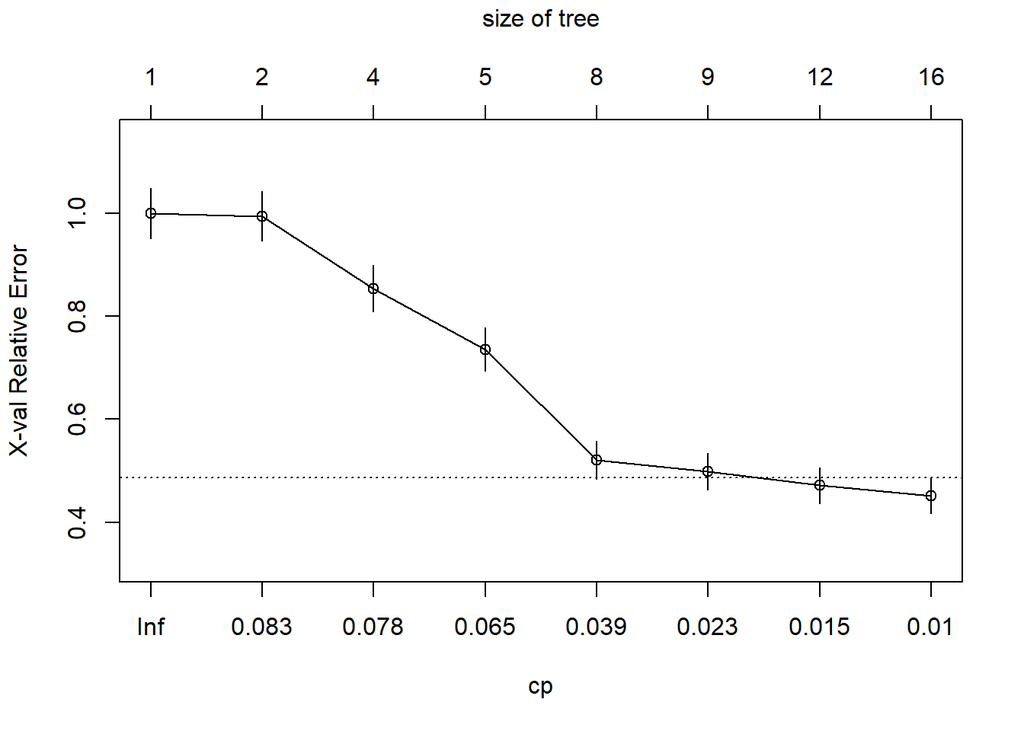

```r
plotcp(Dec_Tree.model)
```

```r
#The base model accuracy as seen above is 93.99% (94% approx)

# Pre-Pruning
# Growing a tree with minsplit of 50 and maxdepth of 6
Dec_Tree.model_preprun <- rpart(churn ~ ., data = Train_Data, method = "class", control = rpart.control(cp=0,minsplit = 50,maxdepth = 6))

# predicting the above pre-pruned tree on the validation set
churn.dec.validate.preprun <- predict(Dec_Tree.model_preprun, Validation_Data, type = "prob")
churn.dec.validate.preprun.df <- cbind(Validation_Data,churn.dec.validate.preprun)

#Optimal K
ROC_pred_dec.pre_test <- prediction(churn.dec.validate.preprun[,1],churn.dec.validate.preprun.df$churn)

ROCR_perf_dec.pre_test <- performance(ROC_pred_dec.pre_test,'tpr','fpr')

acc_dec.pre_perf <- performance(ROC_pred_dec.pre_test,"acc")

ROC_pred_dec.pre_test@cutoffs[[1]][which.max(acc_dec.pre_perf@y.values[[1]])]
```

```
##      3169
## 0.7857143
```

```r
#AUC Value
roc.curve(churn.dec.validate.preprun.df$churn,churn.dec.validate.preprun[,1], plotit = F)
```

```
## Area under the curve (AUC): 0.890
```

```r
#Calculating Accuracy
churn.dec.validate.preprun.df$prob <- as.factor(ifelse(churn.dec.validate.preprun.df$`1`>0.7857143,1,0))

accuracy_preprun <- mean(churn.dec.validate.preprun.df$churn==churn.dec.validate.preprun.df$prob)
accuracy_preprun
```

```
## [1] 0.921875
```

```r
#Post- Pruning
# Pruning the Dec_Tree.model based on the optimal cp value
Dec_tree.model_pruned <- prune(Dec_Tree.model, cp = 0.0100)

#predicting the above pruned tree on the validation set
churn.dec.validate.pruned <- predict(Dec_tree.model_pruned, Validation_Data, type = "prob")
churn.dec.validate.pruned.df <- cbind(Validation_Data,churn.dec.validate.pruned)

#Optimal K
ROC_pred_dec.pos_test <- prediction(churn.dec.validate.pruned[,1],churn.dec.validate.pruned.df$churn)

ROCR_perf_dec.pos_test <- performance(ROC_pred_dec.pos_test,'tpr','fpr')

acc_dec.pos_perf <- performance(ROC_pred_dec.pos_test,"acc")

ROC_pred_dec.pos_test@cutoffs[[1]][which.max(acc_dec.pos_perf@y.values[[1]])]
```

```
##      3304
## 0.3076923
```

```r
#AUC Value
roc.curve(churn.dec.validate.pruned.df$churn,churn.dec.validate.pruned[,1], plotit = F)
```

```
## Area under the curve (AUC): 0.899
```

```r
#Calculating Accuracy
churn.dec.validate.pruned.df$prob <- as.factor(ifelse(churn.dec.validate.pruned.df$`1`>0.3076923,1,0))

accuracy_postprun <- mean(churn.dec.validate.pruned.df$churn==churn.dec.validate.pruned.df$prob)
accuracy_postprun
```

```
## [1] 0.9399038
```

```r
#Comparing the base mode, pre-pruning model and post pruning model's accuracy
#Base model accuracy = 0.9399038
data.frame(accuracy_preprun, accuracy_postprun)
```

```
##   accuracy_preprun accuracy_postprun
## 1         0.921875         0.9399038
```

#Pruning can not have significant impact when the data is imbalanced and this can be a possible reason to not see any change in the accuracy in “post - pruning model”. We are thereby affirming to the base model and using the base model (Dec_Tree_Model) to predict the test set.#

#Prediction on the test set

```r
#Re-coding the variables as being used in the train set
Customers_To_Predict$international_plan <- ifelse(Customers_To_Predict$international_plan =="yes",1,0)
Customers_To_Predict$voice_mail_plan <- ifelse(Customers_To_Predict$voice_mail_plan =="yes",1,0)

#Predicting the decision tree model built over the unseen data
dec.test <- predict(Dec_Tree.model,Customers_To_Predict,type="prob")
churn.dec.test <- cbind(Customers_To_Predict,dec.test)

#Setting the baseline model cutoff point i.e. 0.3076923 on the test set
churn.dec.test$prob <- as.factor(ifelse(churn.dec.test$`1`>0.3076923,"yes","no"))

#Deleting the probability columns 1 and 0
churn.dec.test <- churn.dec.test[,-c(20:21)]
```

*The final file to look for the churns and no churns is the churn.dec.test*